# An assignment of Reproducible Research

Apichart Thanomkiet

2016-09-25

## Loading and preprocessing the data

I have set global option echo = TRUE for each code chunk.

```r
knitr::opts_chunk$set(echo=TRUE, result="hide")
```

I download the file from the internet and save it into my workplace directory. The file locates [here](https://d396qusza40orc.cloudfront.net/repdata%2Fdata%2Factivity.zip). Also, I don’t want it to download the file every time so I am going to cache it.

```r
download.file("https://d396qusza40orc.cloudfront.net/repdata%2Fdata%2Factivity.zip", destfile = paste0(getwd(),"/","file.zip"))
```

I unzip the file and it the file will be extracted into my work directory automatically. I will cache it to prevent it from unzipping everytime.

```r
unzip("file.zip")
```

The extracted file called activity.csv. I will use read.csv() to read the file into a data frame called data.

Also I don’t want it to load the data everytime I rendle the Rmarkdown file so I will cache it.

```r
data <- read.csv("activity.csv")
dim(data)
```

```
## [1] 17568     3
```

## What is mean total number of steps taken per day?

I break down the steps for each day and plot a histogram the graph to see the quanity of the steps. However I break it down by aggregating the data frame So I have to reassignt he column name.

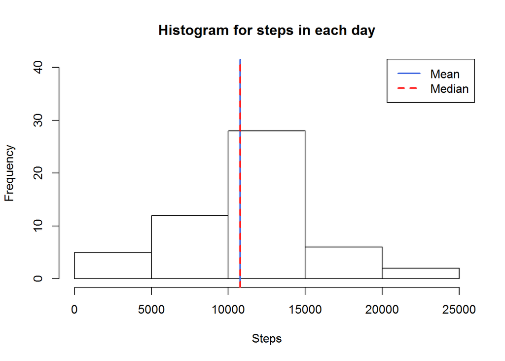

```r
agg <- aggregate(data$step, by=list(data$date), sum)
names(agg) <- c("date","step")
with(agg, hist(step, main="Histogram for steps in each day", xlab="Steps",ylim=c(0,40)))

abline(v = mean(agg$step,na.rm=TRUE),col = "royalblue",
 lwd = 2)

abline(v = median(agg$step,na.rm=TRUE),
 col = "red",
 lwd = 2, lty=2)

legend(x = "topright",
 c("Mean", "Median"),
 col = c("royalblue", "red"),
 lwd = c( 2, 2),
 lty = c(1,2 ))
```

## What is the average daily activity pattern?

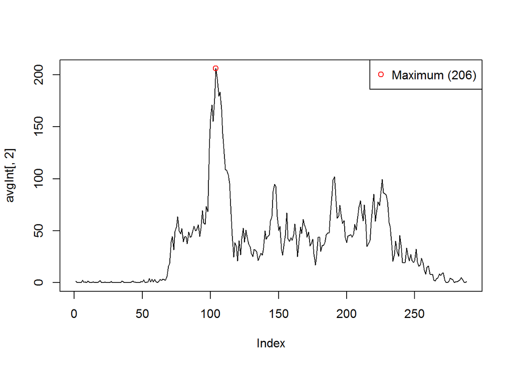

```r
avgInt <- aggregate(data$steps, by=list(data$interval), mean, na.rm=TRUE)
plot(avgInt[,2], type="l")
points(which.max(avgInt[,2]),avgInt[which.max(avgInt[,2]),2], col="red")
legend(x="topright", paste0("Maximum (",round(max(avgInt[,2])),")"), col="red", pch=1)
```

## Imputing missing values

Just to get an Idea how to deal with the NAs. I first want to check which variable that contains the NAs

```r
colnames(data)[colSums(is.na(data)) > 0]
```

```
## [1] "steps"
```

Now I want to see how many NAs in steps

```r
table(is.na(data$steps))
```

```
##
## FALSE  TRUE
## 15264  2304
```

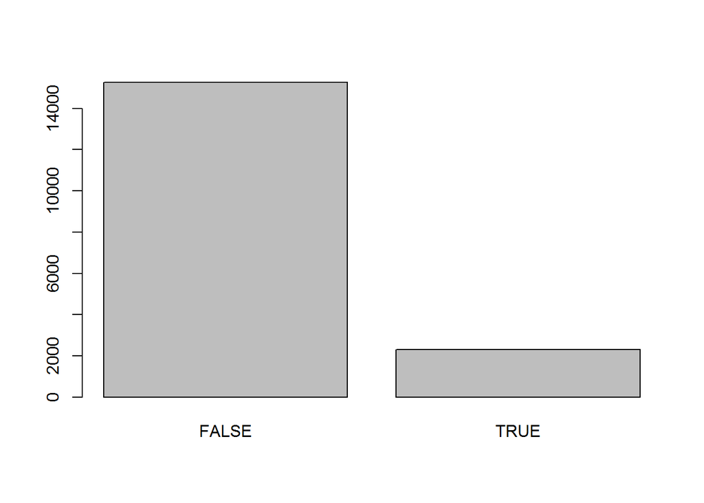

```r
barplot(table(is.na(data$steps)))
```

Now I want to impute these NAs to the data frame that I loaded from the begining. As per instruction, there are two options you can choose. I choose to get the average from 5 interval time.

```r
beforeImpulData <- data

missing <- data[is.na(data$steps),]
data[is.na(data$steps),1] <- sapply(missing$interval, function(x){ avgInt[which(avgInt[,1]==x),2] })
```

Lets see the differences before and after imputing NA values.

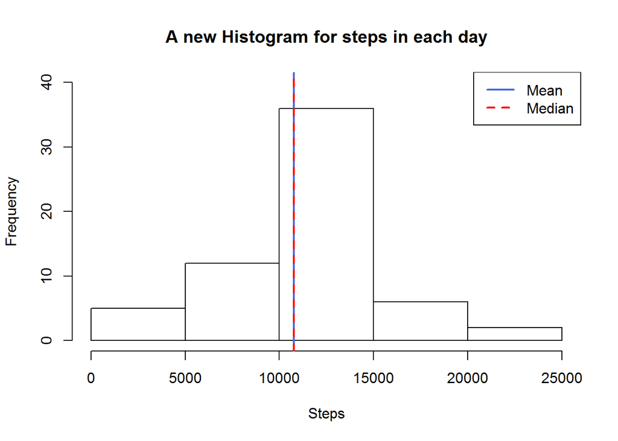

```r
newAgg <- aggregate(data$steps, by=list(data$date), sum)
names(newAgg) <- c("date", "step")
with(newAgg, hist(step, main="A new Histogram for steps in each day", xlab="Steps",ylim=c(0,40)))

abline(v = mean(newAgg$step,na.rm=TRUE),col = "royalblue",
 lwd = 2)

abline(v = median(newAgg$step,na.rm=TRUE),
 col = "red",
 lwd = 2, lty=2)

legend(x = "topright",
 c("Mean", "Median"),
 col = c("royalblue", "red"),
 lwd = c( 2, 2),
 lty = c(1,2 ))
```

It looks really similar from the original one, doesn’t it? I have to see both of them at the same time to tell what are really different. I am going to plot two graphs next to each other.

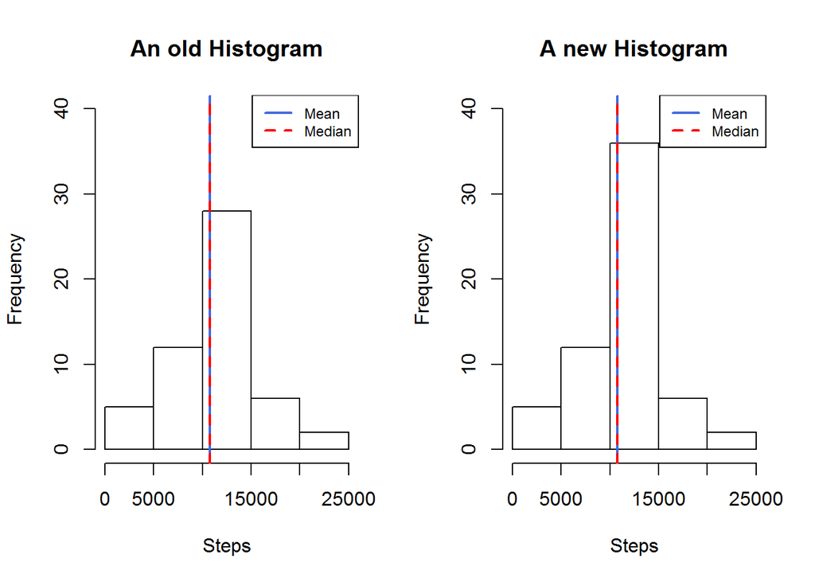

```r
par(mfrow=c(1,2))

with(agg, hist(step, main="An old Histogram", xlab="Steps",ylim=c(0,40)))
abline(v = mean(agg$step,na.rm=TRUE),col = "royalblue",
 lwd = 2)

abline(v = median(agg$step,na.rm=TRUE),
 col = "red",
 lwd = 2, lty=2)

legend(x = "topright",
 c("Mean", "Median"),
 col = c("royalblue", "red"),
 lwd = c( 2, 2),
 lty = c(1,2 ), cex=0.75)


with(newAgg, hist(step, main="A new Histogram", xlab="Steps",ylim=c(0,40)))

abline(v = mean(newAgg$step,na.rm=TRUE),col = "royalblue",
 lwd = 2)

abline(v = median(newAgg$step,na.rm=TRUE),
 col = "red",
 lwd = 2, lty=2)

legend(x = "topright",
 c("Mean", "Median"),
 col = c("royalblue", "red"),
 lwd = c( 2, 2),
 lty = c(1,2 ), cex = 0.75)
```

### What are the differences? What are the impacts?

- Not much different. The only thing that I notice is the increasing of the number of observations.

## Are there differences in activity patterns between weekdays and weekends?

I will make a factor variable called weekdayorweekend and include it into the data frame.

```r
data$date <- as.Date(data$date,"%Y-%m-%d")
wday <- sapply(data$date, function(x){ if(grepl("^S(at|un)", weekdays(x, abbr=TRUE))) "Weekend" else "Weekday" })

newData <- cbind(data, weekdayorweekend=wday)
```

Now lets see the summary

```r
summary(newData)
```

```
##      steps             date               interval      weekdayorweekend
##  Min.   :  0.00   Min.   :2012-10-01   Min.   :   0.0   Weekday:12960
##  1st Qu.:  0.00   1st Qu.:2012-10-16   1st Qu.: 588.8   Weekend: 4608
##  Median :  0.00   Median :2012-10-31   Median :1177.5
##  Mean   : 37.38   Mean   :2012-10-31   Mean   :1177.5
##  3rd Qu.: 27.00   3rd Qu.:2012-11-15   3rd Qu.:1766.2
##  Max.   :806.00   Max.   :2012-11-30   Max.   :2355.0
```

Lastly, I will plot a graph to show how average of steps from each interval goes witht the weekday and weekend.

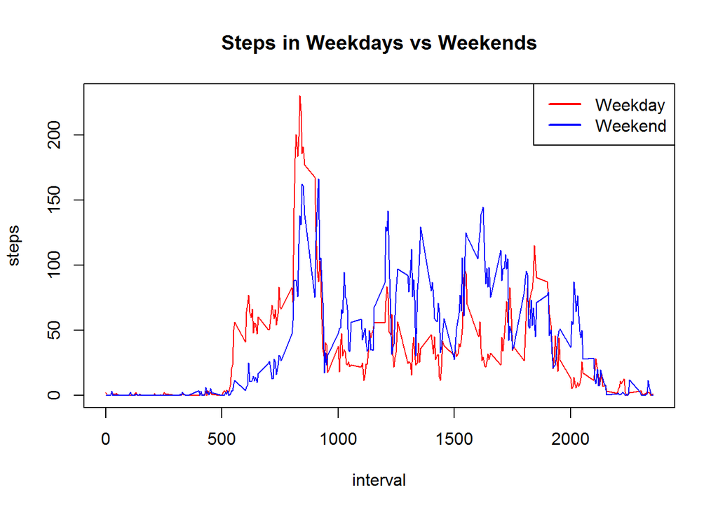

```r
aggData <- aggregate(newData$steps, by=list(newData$interval,newData$weekdayorweekend), mean)
names(aggData) <- c("interval","wday","steps")
weekday <- aggData[aggData$wday == "Weekday",]
weekend <- aggData[aggData$wday == "Weekend",]

with(weekday, plot(interval,steps, type="l", col="red", main="Steps in Weekdays vs Weekends"))
with(weekend, lines(interval, steps, type="l", col="blue"))
legend(x="topright",c("Weekday", "Weekend"), lwd=c(2,2), col=c("red","blue"))
```